# 2018 Ford GoBike System Data

## Preliminary Wrangling

> This data set includes information about individual rides made in a bike-sharing system covering the greater San Francisco Bay area (San Francisco, East Bay, San Jose). This dataset requires some data wrangling in order to make it tidy for analysis. There are multiple data files that will need to be joined together for a full year’s coverage.

```python
#Import all packages and set plots to be embedded inline
import numpy as np
import pandas as pd
import matplotlib.pyplot as plt
import seaborn as sb
import datetime
from haversine import haversine, Unit
import glob
%matplotlib inline
```

```python
#Change display options
pd.set_option('display.max_rows', 500)
pd.set_option('display.max_columns', 500)
pd.set_option('display.width', 1000)
```

> Load in your dataset and describe its properties through the questions below. Try and motivate your exploration goals through this section.

```python
#Read multiple datasets with the same columns in a for loop
all_files= glob.glob('*fordgobike-tripdata.csv')

list_file = []

for file in all_files:
    df = pd.read_csv(file, index_col=None, header=0)
    list_file.append(df)

df = pd.concat(list_file, sort=True, axis=0, ignore_index=True)
```

```python
#Reveal the size of the data
df.shape
```

```
(1863721, 14)
```

```python
#Summary of the data
df.info(verbose=True, null_counts=True)
```

```
<class 'pandas.core.frame.DataFrame'>
RangeIndex: 1863721 entries, 0 to 1863720
Data columns (total 14 columns):
bike_id                    1863721 non-null int64
bike_share_for_all_trip    1863721 non-null object
duration_sec               1863721 non-null int64
end_station_id             1851950 non-null float64
end_station_latitude       1863721 non-null float64
end_station_longitude      1863721 non-null float64
end_station_name           1851950 non-null object
end_time                   1863721 non-null object
start_station_id           1851950 non-null float64
start_station_latitude     1863721 non-null float64
start_station_longitude    1863721 non-null float64
start_station_name         1851950 non-null object
start_time                 1863721 non-null object
user_type                  1863721 non-null object
dtypes: float64(6), int64(2), object(6)
memory usage: 199.1+ MB
```

```python
#Check for duplicate rows
sum(df.duplicated())
```

```
0
```

##### Convert start time into datetime format

```python
df['start_time'] = pd.to_datetime(df['start_time'])

#Sort values by start time
df = df.sort_values(by = 'start_time')
```

##### Given that the trip duration is in seconds, it needs to be converted to minutes, a more natural unit of analysis

```python
df['duration_min'] = df['duration_sec']/60
```

##### Split datetime values into different columns

```python
#Display start time month
df['start_time_month'] = df['start_time'].dt.month
#Display start time hour
df['start_time_hour'] = df['start_time'].dt.hour
#Display start time day
df['start_time_day'] = df['start_time'].dt.weekday_name
```

##### Reorder the start time weekdays, a more natural order

```python
df['start_time_day'] = pd.Categorical(df['start_time_day'],
                        categories=['Monday','Tuesday','Wednesday','Thursday','Friday','Saturday', 'Sunday'], ordered=True)
```

##### Create trip column that concatenates the start and end stations

```python
df['trip'] = df['start_station_name'].str.cat(df['end_station_name'], sep=' to ')

#Replace Null values with 'None'
df['trip']= df.trip.fillna('None')
```

##### Calculate the distance between the start and end stations

```python
df['trip_distance_km'] = df.apply(lambda x: haversine((x['start_station_latitude'],
                            x['start_station_longitude']), (x['end_station_latitude'],
                            x['end_station_longitude']), unit='km'), axis=1)
```

##### Drop unnecessary columns

```python
df.drop(['bike_share_for_all_trip', 'duration_sec', 'end_station_id', 'end_station_name', 'end_time',
         'start_station_id', 'start_station_name' , 'start_time', 'start_station_latitude',
         'start_station_longitude', 'end_station_latitude', 'end_station_longitude'], axis = 1, inplace = True)
```

```python
#Summary of the data
df.info(verbose=True, null_counts=True)
```

```
<class 'pandas.core.frame.DataFrame'>
Int64Index: 1863721 entries, 94662 to 1732362
Data columns (total 8 columns):
bike_id             1863721 non-null int64
user_type           1863721 non-null object
duration_min        1863721 non-null float64
start_time_month    1863721 non-null int64
start_time_hour     1863721 non-null int64
start_time_day      1863721 non-null category
trip                1863721 non-null object
trip_distance_km    1863721 non-null float64
dtypes: category(1), float64(2), int64(3), object(2)
memory usage: 115.5+ MB
```

### What is the structure of your dataset?

> The raw combined 2018 Ford GoBike System Data contains 1,863,721 rows (trips) and 14 columns which was reduced to 8 columns. The column names are shown above.

### What is/are the main feature(s) of interest in your dataset?

> The main features of interest are as follows:
> - Popular times of travel (i.e. occurs most often in the start time)
> - Trip duration
> - Trip distance
> - Behavior of subscribers vs customers

### What features in the dataset do you think will help support your investigation into your feature(s) of interest?

> The features of interest are shown in the above cell.

## Univariate Exploration

### Trip Duration

```python
#Check for outliers
df['duration_min'].describe(percentiles = [.1, .2, .3, .4, .5, .6, .7, .75, .8, .9, .95])
```

```
count    1.863721e+06
mean     1.428838e+01
std      3.950631e+01
min      1.016667e+00
10%      3.816667e+00
20%      5.200000e+00
30%      6.466667e+00
40%      7.800000e+00
50%      9.266667e+00
60%      1.095000e+01
70%      1.313333e+01
75%      1.453333e+01
80%      1.625000e+01
90%      2.230000e+01
95%      3.028333e+01
max      1.439433e+03
Name: duration_min, dtype: float64
```

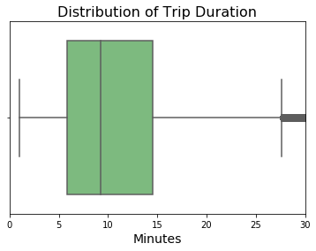

```python
#Create a boxplot function
def boxplot(a,b,c,d):
    sb.boxplot(x= a, data = df, palette='Greens', orient='h')
    plt.title(b, fontsize=16)
    plt.xlabel(c, fontsize=14)
    plt.xlim(d)
    plt.show()

#Plot a boxplot of the trip duration
boxplot('duration_min','Distribution of Trip Duration', 'Minutes', [0, 30])
```

```python
#Create a new data frame that only include rides traveled 27 min or less
df = df[df['duration_min']<=27]
```

```python
#Determine the new mean
df.duration_min.mean()
```

```
9.933857773279618
```

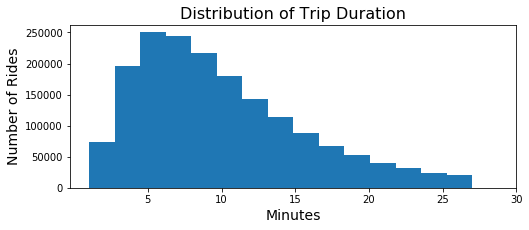

```python
#Create a histogram function
def histogram(a,b,c,d,e):
    plt.figure(figsize=(8,3))
    plt.hist(a, bins = b)
    plt.xlabel(c, fontsize= 14)
    plt.ylabel('Number of Rides', fontsize= 14)
    #start, end, difference - x ticks
    plt.xticks(d)
    plt.title(e, fontsize=16)
    plt.show()

#Plot a histogram of the trip duration
histogram(df['duration_min'], 15, 'Minutes', np.arange(5,35,5), 'Distribution of Trip Duration')
```

### Trip Distance

> The distribution is skewed to the right with outliers above 4: "minimum":0, Q1≈1, medium(Q2):1.3, Q3≈2, "maximum"≈4. The longest distance is 0.8 km.

```python
#Check for outliers
df['trip_distance_km'].describe(percentiles = [.1, .2, .3, .4, .5, .6, .7, .75, .8, .9, .95])
```

```
count    1.742748e+06
mean     1.559565e+00
std      9.398458e-01
min      0.000000e+00
10%      5.862870e-01
20%      7.857344e-01
30%      9.655455e-01
40%      1.161726e+00
50%      1.368810e+00
60%      1.577400e+00
70%      1.875666e+00
75%      2.052599e+00
80%      2.242974e+00
90%      2.869330e+00
95%      3.416979e+00
max      1.222104e+01
Name: trip_distance_km, dtype: float64
```

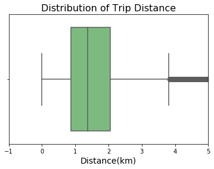

```python
#Plot a boxplot of the trip duration
boxplot('trip_distance_km', 'Distribution of Trip Distance', 'Distance(km)', [-1, 5])
```

```python
#Create a new data frame that only include rides traveled less than 4km
df = df[df['trip_distance_km']< 4]
```

```python
#Determine the new mean
df.trip_distance_km.mean()
```

```
1.4965928862377662
```

```python
#Summary of the new data
df.info(verbose=True, null_counts=True)
```

```
<class 'pandas.core.frame.DataFrame'>
Int64Index: 1707018 entries, 94801 to 1732371
Data columns (total 8 columns):
bike_id             1707018 non-null int64
user_type           1707018 non-null object
duration_min        1707018 non-null float64
start_time_month    1707018 non-null int64
start_time_hour     1707018 non-null int64
start_time_day      1707018 non-null category
trip                1707018 non-null object
trip_distance_km    1707018 non-null float64
dtypes: category(1), float64(2), int64(3), object(2)
memory usage: 105.8+ MB
```

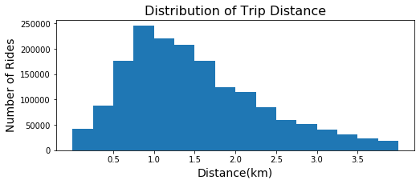

```python
#Plot a histogram of the trip distance
histogram(df['trip_distance_km'], 16, 'Distance(km)', np.arange(0.5,4,0.5), 'Distribution of Trip Distance')
```

### Types of Users

> An overwhelming number of users are subscribers (87.7%).

```python
#Check the type of users
df.groupby('user_type').size()
```

```
user_type
Customer       209499
Subscriber    1497519
dtype: int64
```

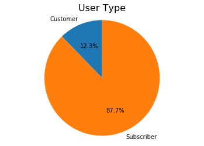

```python
#Create a pie chart of the User Type
r= df.groupby('user_type').size()
y= 'Customer', 'Subscriber'
plt.pie(r, labels= y, autopct='%1.1f%%', startangle=90)
plt.title('User Type', fontsize= 16)
plt.axis('equal')
plt.show()
```

### Monthly Bike Ride Trend

> Overall, the monthly bike ride gradually increased and plateaued, peaking in October, and followed by a dramatic drop in November and December.

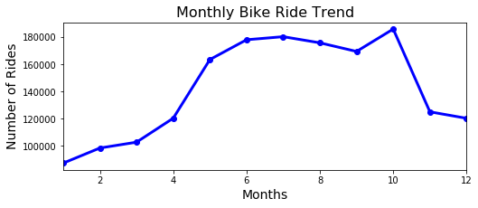

```python
#Create a linegraph function
def linegraph(a,b,c,d):
    a.plot(kind='line', color= b,  marker='o', linewidth=3, figsize=(8,3))
    plt.xlabel(c, fontsize=14)
    plt.ylabel('Number of Rides', fontsize=14)
    plt.title(d, fontsize=16)
    plt.show()

#Create a bar plot of the monthly bike ride trend
linegraph(df.groupby('start_time_month').size(), 'b', 'Months', 'Monthly Bike Ride Trend')
```

### Hourly Bike Ride Trend

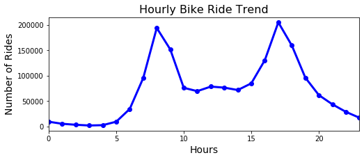

```python
#Create a bar plot of the hourly bike ride trend
linegraph(df.groupby('start_time_hour').size(), 'b', 'Hours', 'Hourly Bike Ride Trend')
```

### Daily Bike Ride Trend

> While the highest peak is on Tuesday, followed by Wednesday and Thursday, the lowest peaks are on the weekend.

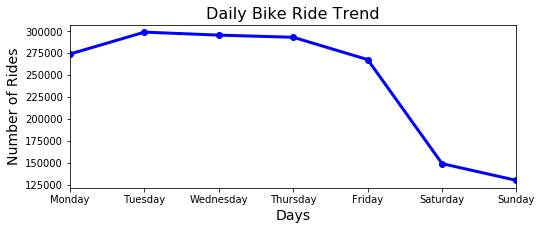

```python
#Create a bar plot of the daily bike ride trend
linegraph(df.groupby('start_time_day').size(), 'b', 'Days', 'Daily Bike Ride Trend')
```

### Top 10 Popular Trips

> The most popular trip is from the San Francisco Ferry Building (Harry Bridges Plaza) to the Embarcadero at Sansome St.

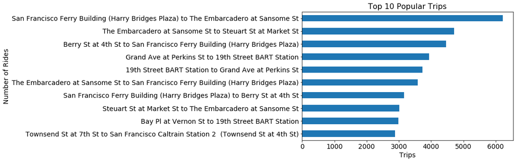

```python
#Create a barplot function
def barplot(a,b,c):
    a.plot(kind='barh', figsize=(8,5))
    plt.xlabel(b, fontsize=14)
    plt.ylabel('Number of Rides', fontsize=14)
    plt.title(c, fontsize=16)
    ax = plt.gca()
    ax.tick_params(labelsize = 14)
    plt.show()

#Create a bar plot of the popular trips
top_10 = df.groupby(['trip']).size().sort_values(ascending=True)[-11:]
top_10= top_10.drop(['None'], axis=0)
barplot(top_10, 'Trips', 'Top 10 Popular Trips')
```

### Of the features you investigated, were there any unusual distributions? Did you perform any operations on the data to tidy, adjust, or change the form of the data? If so, why did you do this?

> The trip duration and distance distributions revealed outliers, some of which were very extreme. Therefore, they were removed. Given that the trip duration is in seconds, it was converted to minutes because it is a more natural unit of analysis. In addition, the start time was converted into the datetime format so that the datetime values can be split into different columns. The start time weekdays were reordered to a more natural order. A trip column was created by concatenating the start and end stations and replacing the null values with 'None'.

## Bivariate Exploration

### Trip Duration vs Trip Distance

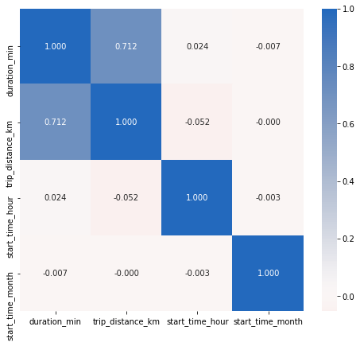

```python
#Create a linear correlation plot
numeric_vars = ['duration_min', 'trip_distance_km', 'start_time_hour', 'start_time_month']
categoric_vars = ['user_type', 'start_time_day']

plt.figure(figsize = [8, 7])
sb.heatmap(df[numeric_vars].corr(), annot = True, fmt = '.3f',
           cmap = 'vlag_r', center = 0)

b, t = plt.ylim() # discover the values for bottom and top
b += 0.5 # Add 0.5 to the bottom
t -= 0.5 # Subtract 0.5 from the top
plt.ylim(b, t) # update the ylim(bottom, top) values
plt.show()
```

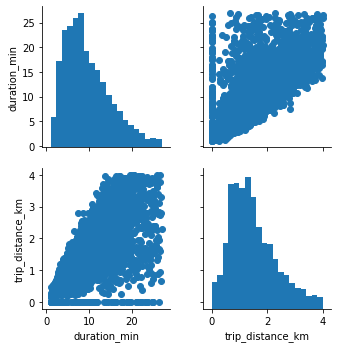

```python
# Create a matrix plot: sample 5000 trips so that plots are clearer and they render faster
df_2= df[['duration_min', 'trip_distance_km']]

samples = np.random.choice(df_2.shape[0], 5000, replace = False)
df_2_samp = df_2.loc[samples,:]

numeric_vars = ['duration_min', 'trip_distance_km']
g = sb.PairGrid(data = df_2_samp, vars = numeric_vars)
g = g.map_diag(plt.hist, bins = 20);
g.map_offdiag(plt.scatter)
```

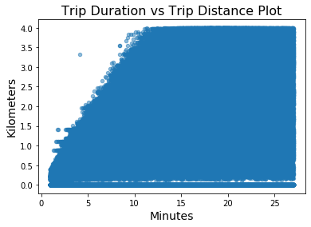

```python
#Create a scatterplot function
def scatterplot(a,b):
    a.plot(kind='scatter',x='duration_min',y='trip_distance_km', alpha = 0.5)
    plt.xlabel('Minutes', fontsize=14)
    plt.ylabel('Kilometers', fontsize=14)
    plt.title(b, fontsize=16)

#Graph Duration vs. Distance
scatterplot(df, 'Trip Duration vs Trip Distance Plot')
```

### Behavior of Subscribers vs Customers

### Trip Duration

> The trip durations for both the customers and subscribers are right-skewed, even more so for subscribers. The peak is at 8 minutes for customers and 5 minutes for subscribers.

```python
#Create subscriber and customer data frames
customer= df.loc[df['user_type'] == 'Customer']
subscriber= df.loc[df['user_type'] == 'Subscriber']
```

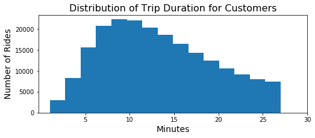

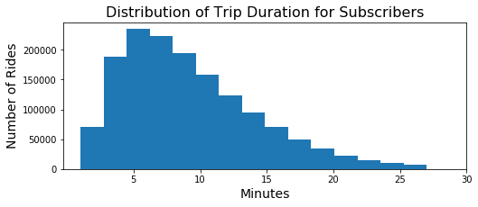

```python
#Plot histograms of the trip duration
histogram(customer['duration_min'], 15, 'Minutes', np.arange(5,35,5), 'Distribution of Trip Duration for Customers')
histogram(subscriber['duration_min'], 15, 'Minutes', np.arange(5,35,5), 'Distribution of Trip Duration for Subscribers')
```

```python
# Determine the mean of the trip duration
cu= customer.duration_min.mean()
su= subscriber.duration_min.mean()
print(cu,su)
```

```
13.249213838729544 9.193951506903707
```

### Trip Distance

> The trip distances for both the customers and subscribers are right-skewed, even more so for subscribers. The peak is at 1.3 km for customers and 0.8 km for subscribers.

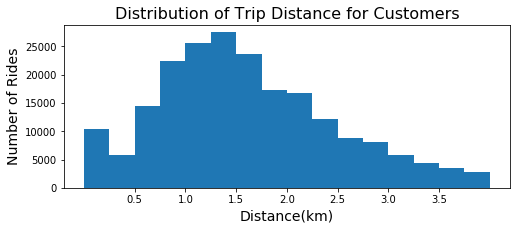

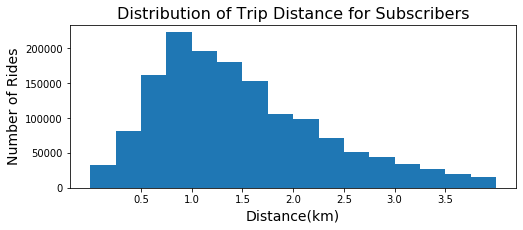

```python
#Plot histograms of the trip distance
histogram(customer['trip_distance_km'], 16, 'Distance(km)', np.arange(0.5,4,0.5),
          'Distribution of Trip Distance for Customers')
histogram(subscriber['trip_distance_km'], 16, 'Distance(km)', np.arange(0.5,4,0.5),
          'Distribution of Trip Distance for Subscribers')
```

```python
# Determine the mean of the trip distance
cu= customer.trip_distance_km.mean()
su= subscriber.trip_distance_km.mean()
print(cu,su)
```

```
1.602117244024444 1.481830303971796
```

### Monthly Bike Ride Trend

> Overall, the monthly bike rides for customers increase then plateaus in May and then decreases. However, the monthly bike rides gradually increases and plateaues, peaking in October, and followed by a dramatic drop in November and December.

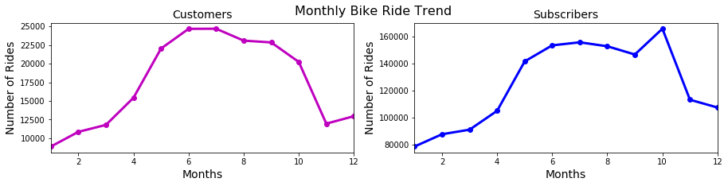

```python
#Create a linegraph function with subplots
def linegraph(a,b,c,d,e,f):
    plt.figure(figsize=(15,3))
    plt.subplot(1,2,1)
    plt.suptitle(a, fontsize=16)
    customer.groupby(b).size().plot(kind='line', color= c,  marker='o', linewidth=3)
    plt.title('Customers', fontsize=14)
    plt.xlabel(e, fontsize=14)
    plt.ylabel(f, fontsize=14)

    plt.subplot(1,2,2)
    subscriber.groupby(b).size().plot(kind='line', color= d,  marker='o', linewidth=3)
    plt.title('Subscribers', fontsize=14)
    plt.xlabel(e, fontsize=14)
    plt.ylabel(f, fontsize=14)

#Create a bar plot of the monthly bike ride trend
linegraph('Monthly Bike Ride Trend', 'start_time_month', 'm', 'b', 'Months', 'Number of Rides')
```

### Hourly Bike Ride Trend

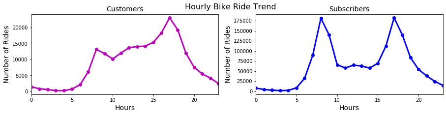

```python
#Create a bar plot of the hourly bike ride trend
linegraph('Hourly Bike Ride Trend', 'start_time_hour', 'm', 'b', 'Hours', 'Number of Rides')
```

### Daily Bike Ride Trend

> The weekend is popular for customers unlike subscribers. Moreover, the weekend is the least popular time for subscribers. Tuesday is the most popular, followed by Wednesday and Thursday among the subscribers. Saturday is the most popular day, followed by Friday and Sunday among the Customers.

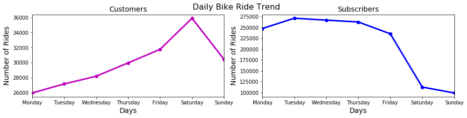

```python
#Create a bar plot of the daily bike ride trend
linegraph('Daily Bike Ride Trend', 'start_time_day', 'm', 'b', 'Days', 'Number of Rides')
```

### Top 10 Popular Trips

> The most popular trips for subscribers and customers are different.

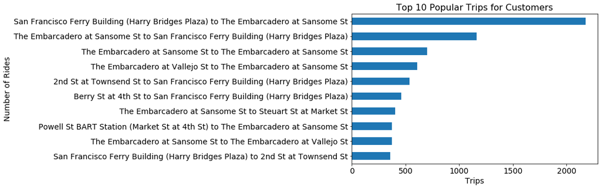

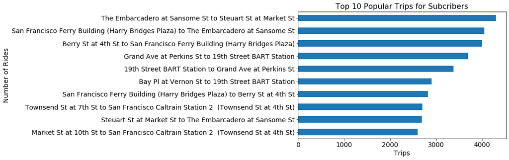

```python
#Create bar plots of the popular trips
top_10_customer = customer.groupby(['trip']).size().sort_values(ascending=True)[-11:]
top_10_customer= top_10_customer.drop(['None'], axis=0)
barplot(top_10_customer, 'Trips', 'Top 10 Popular Trips for Customers')

top_10_subscriber = subscriber.groupby(['trip']).size().sort_values(ascending=True)[-11:]
top_10_subscriber= top_10_subscriber.drop(['None'], axis=0)
barplot(top_10_subscriber, 'Trips', 'Top 10 Popular Trips for Subcribers')
```

### Did you observe any interesting relationships between the other features (not the main feature(s) of interest)?

> There doesn't appear to be a correlation between the other features.

## Multivariate Exploration

### Further Exploration of Subscribers vs Customers

### Average Monthly Trip Distance

> The trends are similar, but customers have slightly higher averages.

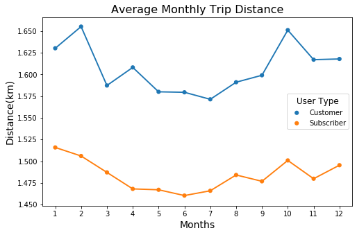

```python
#Create a line function
def line (a,b,c):
    df_x = df.groupby([a, 'user_type'])['trip_distance_km'].mean()
    df_x=df_x.reset_index()

    plt.figure(figsize=(8,5))
    ax = sb.pointplot(x=a, y='trip_distance_km', hue='user_type', scale=.7, data=df_x)
    plt.title(b, fontsize=16,)
    plt.xlabel(c, fontsize=14)
    plt.ylabel('Distance(km)', fontsize=14)
    leg = ax.legend()
    leg.set_title('User Type',prop={'size':12})
    plt.grid(False)

#Plot the Average Monthly Trip Distance
line('start_time_month','Average Monthly Trip Distance', 'Months')
```

### Average Hourly Trip Distance

> The trends are similar, but customers have slightly higher averages.

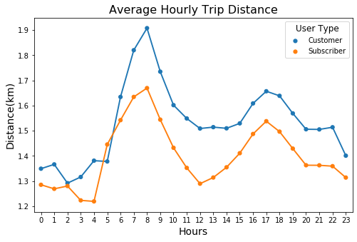

```python
#Plot the Average Hourly Trip Distance
line('start_time_hour','Average Hourly Trip Distance', 'Hours')
```

### Average Daily Trip Distance

> The trends are similar, but customers have slightly higher averages even during the weekend.

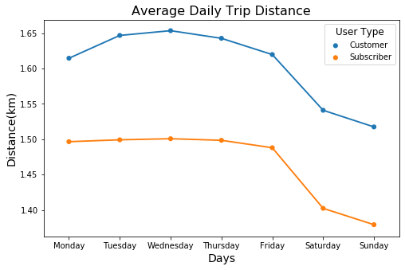

```python
#Plot the Average Daily Trip Distance
line('start_time_day','Average Daily Trip Distance', 'Days')
```

### Further Comparison of Customers and Subscribers During Peak Hours

### Most Frequently Used Daily Trip Durations During Peak Hours

> The most frequently used trips last 5-10 minutes during the weekdays among customers and subscribers. Moreover, customers have similar trip durations to subscribers during the weekend although customers tend to be the most active at that time.

```python
#Create two bin columns
df['trip_distance_km_bins'] = df['trip_distance_km'].apply(lambda x: '0-0.5' if 0<x<=0.5
                                                  else '0.5 - 1' if 0.5<x<=1
                                                  else '1 - 1.5' if 1<x<=1.5
                                                  else '1.5 - 2' if 1.5<x<=2
                                                  else '2 - 2.5' if 2<x<=2.5
                                                  else '2.5 - 3' if 2.5<x<=3
                                                  else '3 - 3.5' if 3<x<=3.5
                                                  else '3.5 - 4' if 3.5<x<=4
                                                  else x)

df['duration_min_bins'] = df['duration_min'].apply(lambda x: '0-5' if 0<x<=5
                                                  else '5-10' if 5<x<=10
                                                  else '10-15' if 10<x<=15
                                                  else '15-20' if 15<x<=20
                                                  else '20-25' if 20<x<=25
                                                  else '25-30' if 25<x<=30
                                                  else x)
```

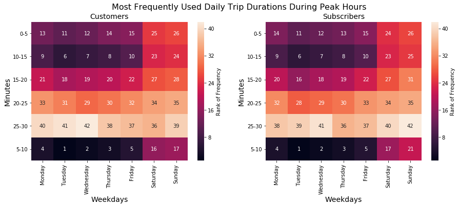

```python
#Create heatmap function
def heatmap(a,b,c,d,e):
    #Create customer and subscriber data frames and restrict the start time hours to only include the peak hours
    customer_h= df[(df['user_type']=='Customer') & (df['start_time_hour']>=7) & (df['start_time_hour']<=10)|
                   (df['start_time_hour'] >= 16) & (df['start_time_hour'] <= 19)].groupby([a,b]).agg({'bike_id':
                                                    'count'}).rename(columns={'bike_id':'count'}).reset_index()

    subscriber_h= df[(df['user_type']=='Subscriber') & (df['start_time_hour']>=7) & (df['start_time_hour']<=10)|
                     (df['start_time_hour'] >= 16) & (df['start_time_hour'] <= 19)].groupby([a,b]).agg({'bike_id':
                                                    'count'}).rename(columns={'bike_id':'count'}).reset_index()

    #Create customer and subscriber percent and rank columns
    customer_h['count_perc'] = customer_h['count'].apply(lambda x: (x/customer_h['count'].sum())*100)
    customer_h['rank'] = customer_h['count_perc'].rank(ascending=False).astype(int)
    customer_h_df_pivoted = customer_h.pivot_table(index=b, columns=a, values='rank').astype(int)

    subscriber_h['count_perc'] = subscriber_h['count'].apply(lambda x: (x/subscriber_h['count'].sum())*100)
    subscriber_h['rank'] = subscriber_h['count_perc'].rank(ascending=False).astype(int)
    subscriber_h_df_pivoted = subscriber_h.pivot_table(index=b, columns=a, values='rank').astype(int)

    #Create heatmaps
    plt.figure(figsize=(15,5))
    plt.subplot(1,2,1)
    plt.suptitle(c, fontsize=16)
    sb.heatmap(customer_h_df_pivoted, annot=True, fmt='d', cbar_kws={'label': 'Rank of Frequency'})
    plt.title('Customers', fontsize=14)
    plt.xlabel(d, fontsize=14)
    plt.ylabel(e, fontsize=14)
    plt.yticks(rotation=360)
    b, t = plt.ylim() # discover the values for bottom and top
    b += 0.5 # Add 0.5 to the bottom
    t -= 0.5 # Subtract 0.5 from the top
    plt.ylim(b, t) # update the ylim(bottom, top) values

    plt.subplot(1,2,2)
    sb.heatmap(subscriber_h_df_pivoted, annot=True, fmt='d', cbar_kws={'label': 'Rank of Frequency'})
    plt.title('Subscribers', fontsize=14)
    plt.xlabel(d, fontsize=14)
    plt.ylabel(e, fontsize=14)
    plt.yticks(rotation=360)
    b, t = plt.ylim() # discover the values for bottom and top
    b += 0.5 # Add 0.5 to the bottom
    t -= 0.5 # Subtract 0.5 from the top
    plt.ylim(b, t) # update the ylim(bottom, top) values

#Plot the most frequently used daily trip durations during peak hours
heatmap('start_time_day','duration_min_bins', 'Most Frequently Used Daily Trip Durations During Peak Hours',
        'Weekdays', 'Minutes')
```

### Most Frequently Used Monthly Trip Durations During Peak Hours

> The most frequently used trips last 5-10 minutes from April through October among customers and subscribers.

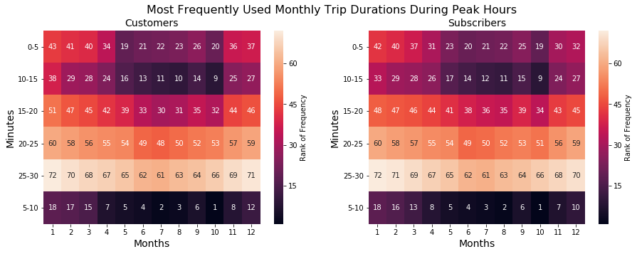

```python
#Plot the most frequently used monthly trip durations during peak hours
heatmap('start_time_month','duration_min_bins', 'Most Frequently Used Monthly Trip Durations During Peak Hours',
        'Months', 'Minutes')
```

### Most Frequently Used Daily Trip Distances During Peak Hours

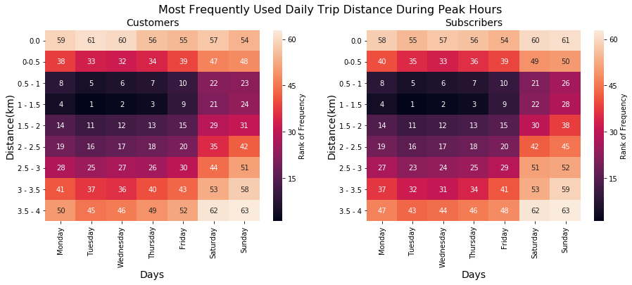

```python
#Plot the most frequently used daily trip distances during peak hours
heatmap('start_time_day','trip_distance_km_bins', 'Most Frequently Used Daily Trip Distance During Peak Hours',
        'Days', 'Distance(km)')
```

### Most Frequently Used Monthly Trip Distances During Peak Hours

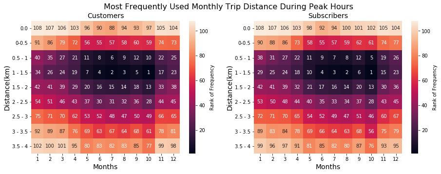

```python
#Most frequently used monthly trip distance during peak hours
heatmap('start_time_month','trip_distance_km_bins', 'Most Frequently Used Monthly Trip Distance During Peak Hours',
        'Months', 'Distance(km)')
```

### Were there any interesting or surprising interactions between features?

> The overall trends for customers and subscribers are very similar. Moreover, customers have similar trip durations and distances to subscribers during the weekend although customers tend to be the most active at that time.